# Model Selection and Grid Search

Jinfei Zhu (jinfei@uchicago.edu)

# Overview

Data Description: Ames housing data, collected by the Ames Assessor’s Office using computing assessed values for individual residential properties sold in Ames, IA from 2006 to 2010.

The codebook and definitions of functions are included in the package documentation note: https://cran.r-project.org/web/packages/AmesHousing/AmesHousing.pdf.

```r
# install.packages(('devtools'))
# library(devtools)
# install_github('uc-cfss/rcfss')

library(leaps)
library(tidyverse)
library(tidymodels)
library(glmnet)
library(leaps)
library(rcfss)
library(patchwork)
library(AmesHousing)

set.seed(1234)
theme_set(theme_minimal())

# Set up
ames_split <- initial_split(AmesHousing::make_ames(),
                            prop = 0.7,
                            strata = "Sale_Price")
ames_train <- training(ames_split)
ames_test  <- testing(ames_split)

head(ames_train)

glimpse(ames_train)

# select numeric features for simpler demo
ames_lite <- ames_train %>%
  select_if(is.numeric)
```

## Best Subset Selection

Best subset selection involves following steps:

1. First, fit the null model, with *no* features with only an intercept
2. Then, we fit a model containing only *one* feature; do this for all models up to p and then pick the best; set it aside
3. Then, we fit a model containing only *two* features; pick the best and set it aside
4. And so on for all features in the model, giving us a look at models fits across possible combinations of features in the data space
5. Finally, select the best model from among this subset to serve as the best model, with the best combination of features

```r
set.seed(1234)

# Fit the model
best_subset <- regsubsets(Sale_Price ~ .,
                          data = ames_lite,
                          nvmax = 34); summary(best_subset)
```

```r
results <- summary(best_subset)

names(results) # prints the "values" returned by fitting via the regsubsets() function
```

```
## [1] "which"  "rsq"    "rss"    "adjr2"  "cp"     "bic"    "outmat" "obj"
```

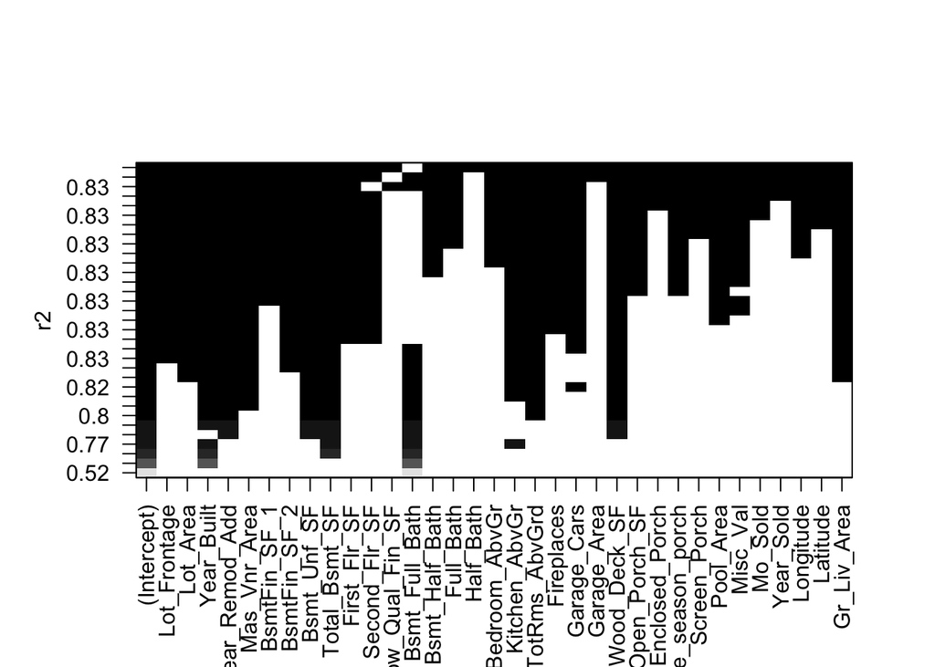

```r
plot(best_subset, scale="r2")
```

```r
# best models per each information loss metric
results_best <- tibble(
  `adj_r2` = which.max(results$adjr2),
  BIC = which.min(results$bic),
  `c_p` = which.min(results$cp)
) %>%
  gather(statistic, best)

results_best
```

```
## # A tibble: 3 × 2
##   statistic  best
##   <chr>     <int>
## 1 adj_r2       24
## 2 BIC          17
## 3 c_p          23
```

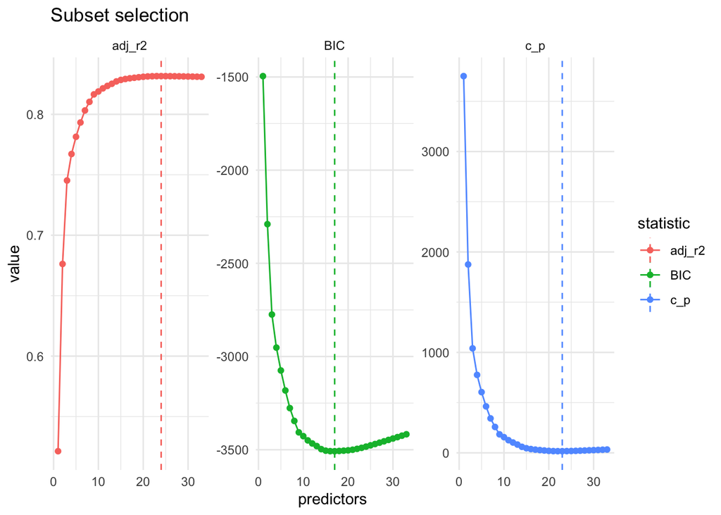

```r
# extract and organize the results; then plot
tibble(`c_p` = results$cp,
       `adj_r2` = results$adjr2,
       BIC = results$bic) %>%
  mutate(predictors = row_number()) %>%
  gather(statistic, value, -predictors) %>%
  ggplot(aes(predictors, value,
             color = statistic)) +
  geom_line() +
  geom_point() +
  geom_vline(data = results_best,
             aes(xintercept = best,
                 color = statistic),
             linetype = 2) +
  facet_wrap(~ statistic, scales = "free") +
  ggtitle("Subset selection")
```

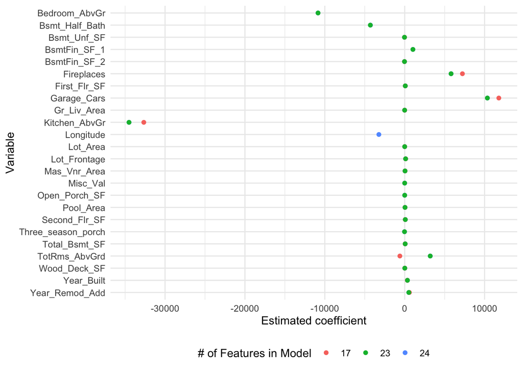

```r
coef(best_subset, results_best$best) %>%
  set_names(results_best$best) %>%
  map(enframe) %>%
  bind_rows(.id = "num_vars") %>%
  filter(name != "(Intercept)") %>%
  ggplot(aes(fct_rev(name), value)) +
  geom_point(aes(color = num_vars)) +
  coord_flip() +
  labs(x = "Variable",
       y = "Estimated coefficient",
       color = "# of Features in Model") +
  theme(legend.position = "bottom")
```

We can use V-fold Cross Validation for evaluation.

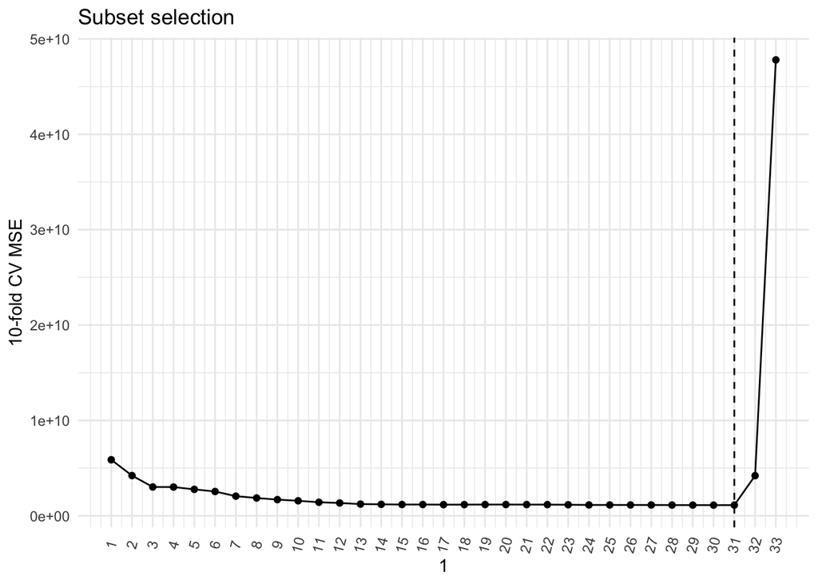

```r
set.seed(1234)

predict.regsubsets <- function(object, newdata, id ,...) {
  form <- as.formula(Sale_Price ~ .)
  mat <- model.matrix(form, newdata)
  coefi <- coef(object, id = id)
  xvars <- names(coefi)
  as.vector(mat[, xvars] %*% coefi, mode = "integer")
}

predict_all <- function(object, newdata, k){
  map(k, ~ predict.regsubsets(object, newdata, id = .x)) %>%
    set_names(k)
}

ames_lite_cv <- vfold_cv(ames_lite, v = 10)

ames_lite_cv <- ames_lite_cv %>%
  mutate(model = map(splits, ~ regsubsets(Sale_Price ~ ., data = analysis(.x), nvmax = 34)),
         pred = map2(model, splits, ~ predict_all(.x, assessment(.y), k = 1:33))) %>%
  unnest(pred, .preserve = splits) %>%
  group_by(id) %>%
  mutate(k = 1:33,
         truth = map(splits, ~ assessment(.x)$Sale_Price)) %>%
  unnest(pred, truth) %>%
  group_by(id, k) %>%
  mse(truth = truth, estimate = pred) %>%
  group_by(k) %>%
  summarize(.estimate = mean(.estimate))

ggplot(ames_lite_cv, aes(k, .estimate)) +
  geom_line() +
  geom_point() +
  scale_x_continuous(ames_lite_cv$k,
                     labels = as.character(ames_lite_cv$k),
                     breaks = ames_lite_cv$k) +
  theme(axis.text.x = element_text(angle = 75, vjust = 0.5)) +
  geom_vline(xintercept = which.min(ames_lite_cv$.estimate), linetype = 2) +
  labs(title = "Subset selection",
       y = "10-fold CV MSE",
       x = "Number of variables")
```

## Forward and Backward Stepwise Selection

A related family of alternatives to best subset are stepwise methods that explore a more restricted set of models, because it’s not always best/computationally tractable to do a *full search of all combinations*.

*Forward stepwise* selection starts with a *null* model like best subset, but adds predictors one at a time until all predictors are in the model. That is, at each step we aren’t searching over all possible modes that contain $k$ (or $p$) predictors. Rather we are looking at models that contain $k − 1$ predictors chosen in the previous step, and then pick variable with biggest improvement over previous version.

```r
set.seed(1234)

forward <- regsubsets(Sale_Price ~ ., ames_lite,
                      nvmax = 34,
                      method = "forward")
```

```
## Reordering variables and trying again:
```

```r
results_forward <- summary(forward)
```

```r
results_forward_best <- tibble(
  `adj_r2` = which.max(results_forward$adjr2),
  BIC = which.min(results_forward$bic),
  `c_p` = which.min(results_forward$cp)
) %>%
  gather(statistic, best)
```

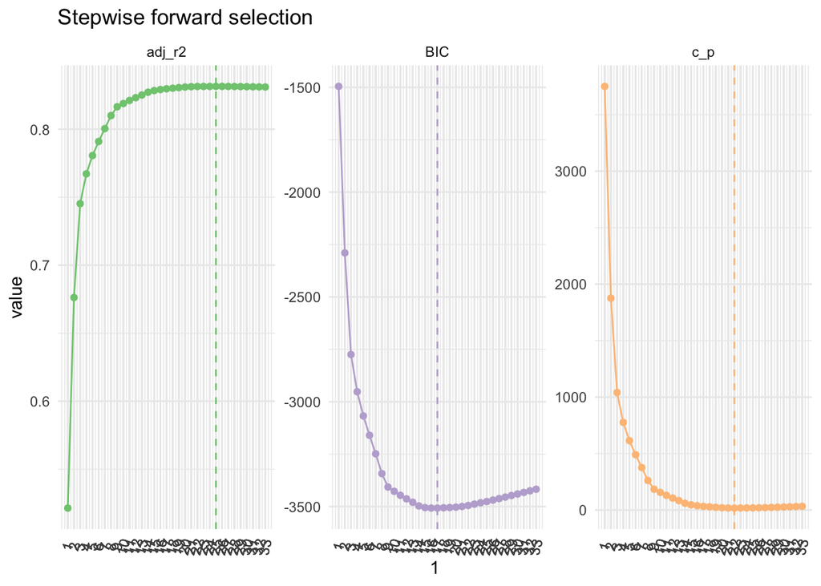

```r
forward_plot_data <- tibble(`c_p` = results_forward$cp,
                            `adj_r2` = results_forward$adjr2,
                            BIC = results_forward$bic) %>%
  mutate(predictors = row_number()) %>%
  gather(statistic, value, -predictors)

forward_plot_data %>%
  ggplot(aes(predictors, value,
             color = statistic)) +
  geom_line() +
  geom_point() +
  scale_x_continuous(forward_plot_data$predictors,
                     labels = as.character(forward_plot_data$predictors),
                     breaks = forward_plot_data$predictors) +
  theme(axis.text.x = element_text(angle = 75, vjust = 0.5)) +
  geom_vline(data = results_forward_best,
             aes(xintercept = best,
                 color = statistic),
             linetype = 2) +
  facet_wrap(~ statistic, scales = "free") +
  scale_color_brewer(type = "qual", guide = FALSE) +
  ggtitle("Stepwise forward selection")
```

Now,*backward stepwise* is same as forward, only it starts with the *full* model and iteratively removes the least useful predictor with each iteration until we get to the intercept only model. The steps are the same, so we will just leave the code in a single chunk.

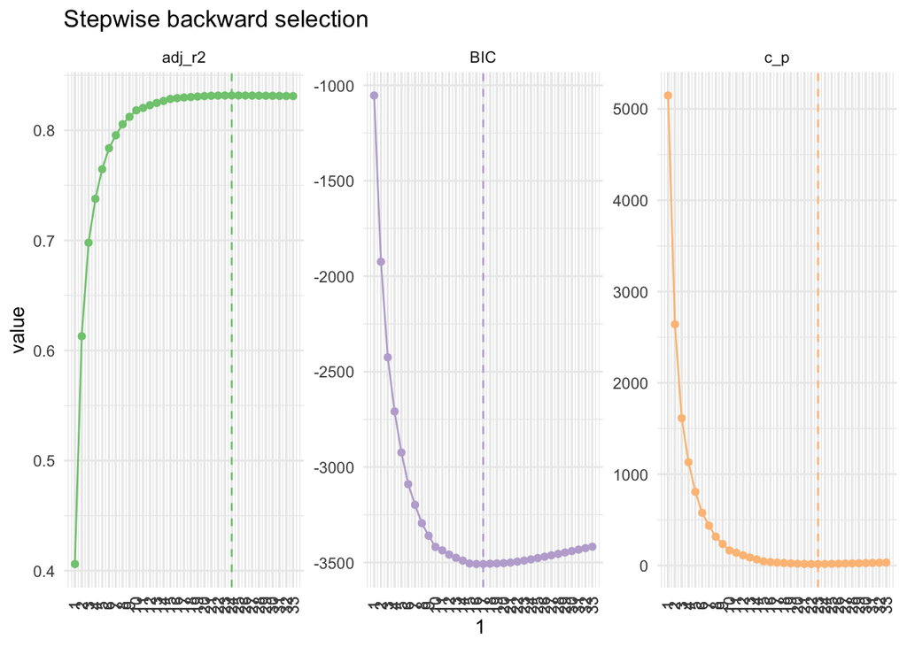

```r
set.seed(1234)

# fit and store
backward <- regsubsets(Sale_Price ~ ., ames_lite,
                       nvmax = 34,
                       method = "backward")

results_backward <- summary(backward)

# best mod per stat
results_backward_best <- tibble(
  `adj_r2` = which.max(results_backward$adjr2),
  BIC = which.min(results_backward$bic),
  `c_p` = which.min(results_backward$cp)
) %>%
  gather(statistic, best)

# extract and store
backward_plot_data <- tibble(`c_p` = results_backward$cp,
                            `adj_r2` = results_backward$adjr2,
                            BIC = results_backward$bic) %>%
  mutate(predictors = row_number()) %>%
  gather(statistic, value, -predictors)

# viz
backward_plot_data %>%
  ggplot(aes(predictors, value,
             color = statistic)) +
  geom_line() +
  geom_point() +
  scale_x_continuous(backward_plot_data$predictors,
                     labels = as.character(backward_plot_data$predictors),
                     breaks = backward_plot_data$predictors) +
  theme(axis.text.x = element_text(angle = 90, vjust = 0.5)) +
  geom_vline(data = results_backward_best,
             aes(xintercept = best,
                 color = statistic),
             linetype = 2) +
  facet_wrap(~ statistic, scales = "free") +
  scale_color_brewer(type = "qual", guide = FALSE) +
  ggtitle("Stepwise backward selection")
```

# Regularization

Now, regularization for regression problems: ridge, LASSO, and elastic net regression.

## Ridge

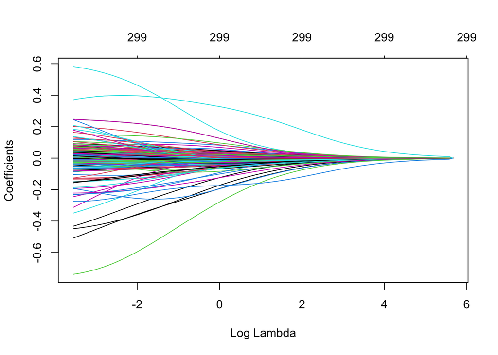

```r
set.seed(1234)

ames_train_x <- model.matrix(Sale_Price ~ ., ames_train)[, -1]
ames_train_y <- log(ames_train$Sale_Price)

ames_test_x <- model.matrix(Sale_Price ~ ., ames_test)[, -1]
ames_test_y <- log(ames_test$Sale_Price)


# First: ridge regression
ames_ridge <- glmnet(
  x = ames_train_x,
  y = ames_train_y,
  alpha = 0
)

plot(ames_ridge, xvar = "lambda")
```

```r
coef(ames_ridge)[c("Gr_Liv_Area", "Year_Built"), 1]
```

```
##  Gr_Liv_Area   Year_Built
## 5.861389e-40 8.253705e-39
```

```r
coef(ames_ridge)[c("Gr_Liv_Area", "Year_Built"), 100]
```

```
##  Gr_Liv_Area   Year_Built
## 0.0001116904 0.0012270836
```

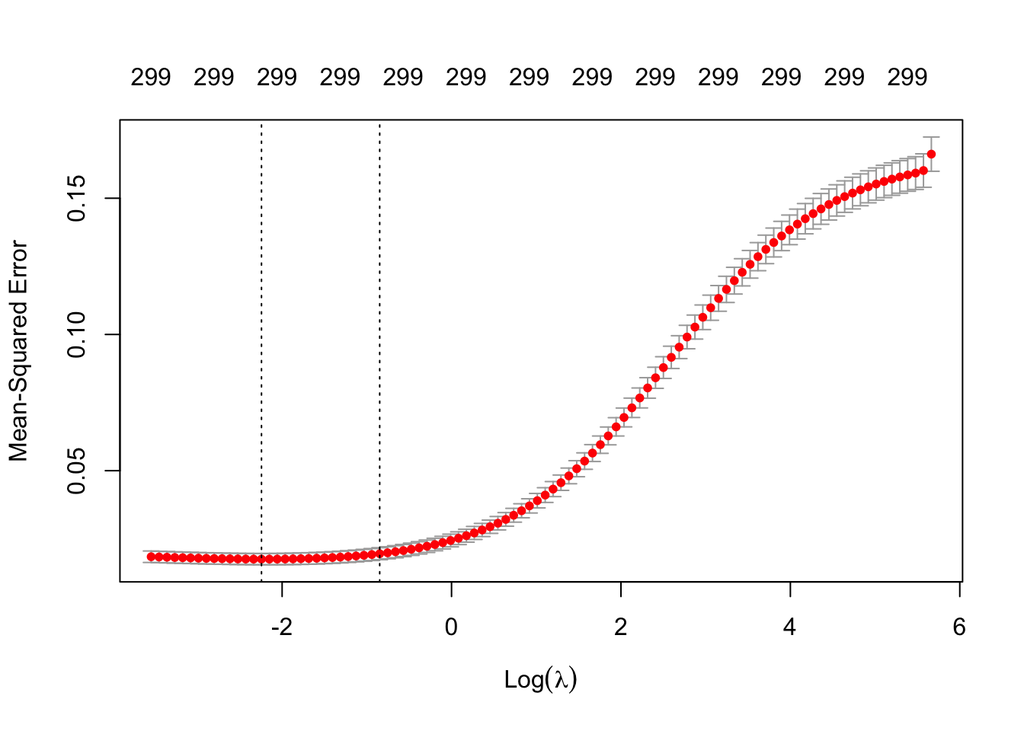

```r
# fit
ames_ridge <- cv.glmnet(
  x = ames_train_x,
  y = ames_train_y,
  alpha = 0
)

# plot CV results
plot(ames_ridge)
```

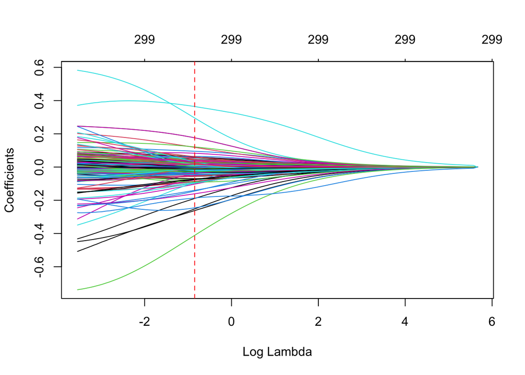

```r
# final, best model based on tuned lambda
ames_ridge_min <- glmnet(
  x = ames_train_x,
  y = ames_train_y,
  alpha = 0
)

plot(ames_ridge_min, xvar = "lambda")
abline(v = log(ames_ridge$lambda.1se), col = "red", lty = "dashed")
```

If you’re interested…

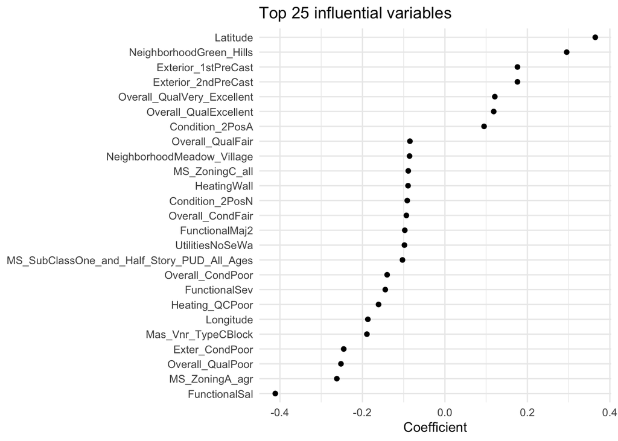

```r
coef(ames_ridge, s = "lambda.1se") %>%
  tidy() %>%
  filter(row != "(Intercept)") %>%
  top_n(25, wt = abs(value)) %>%
  ggplot(aes(value, reorder(row, value))) +
  geom_point() +
  labs(title = "Top 25 influential variables",
       x = "Coefficient",
       y = NULL)
```

## LASSO

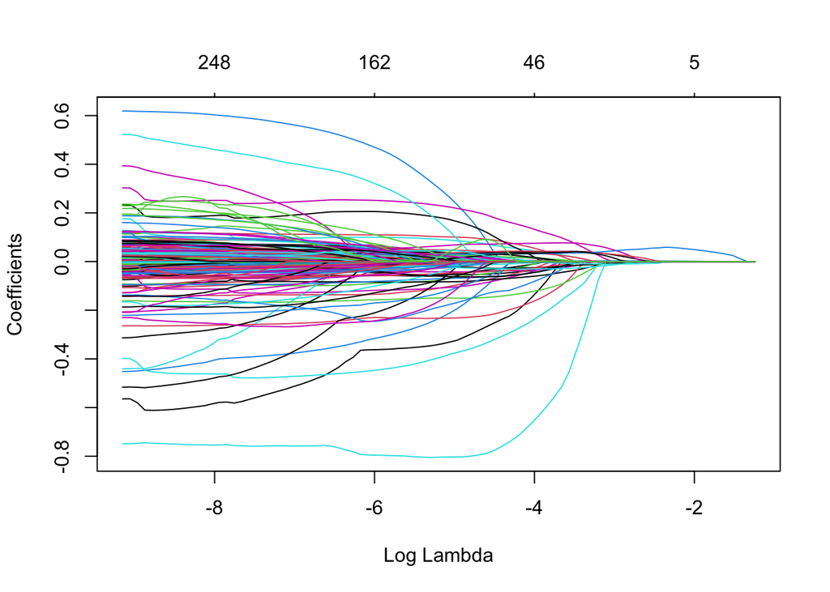

```r
# fit
ames_lasso <- glmnet(
  x = ames_train_x,
  y = ames_train_y,
  alpha = 1
)

plot(ames_lasso, xvar = "lambda")
```

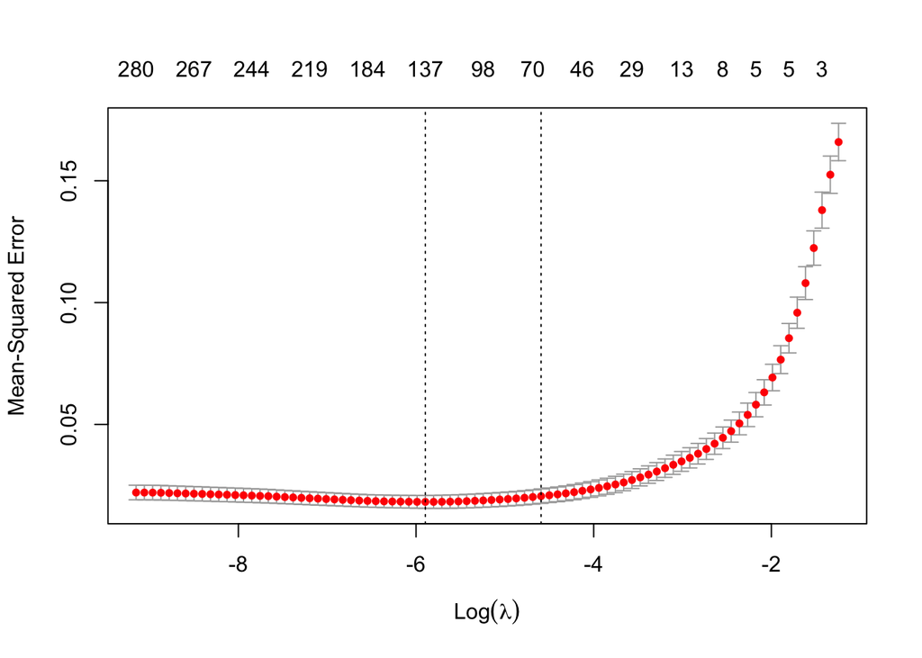

```r
# tuning lambda
ames_lasso <- cv.glmnet(
  x = ames_train_x,
  y = ames_train_y,
  alpha = 1
)

# plot results
plot(ames_lasso)
```

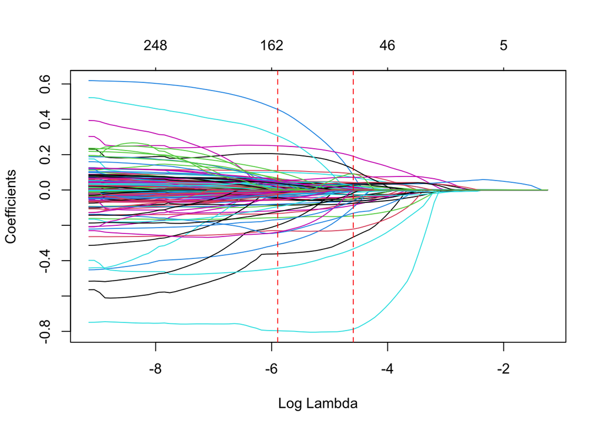

```r
ames_lasso_min <- glmnet(
  x = ames_train_x,
  y = ames_train_y,
  alpha = 1
)

plot(ames_lasso_min, xvar = "lambda")
abline(v = log(ames_lasso$lambda.min), col = "red", lty = "dashed")
abline(v = log(ames_lasso$lambda.1se), col = "red", lty = "dashed")
```

## Elastic Net

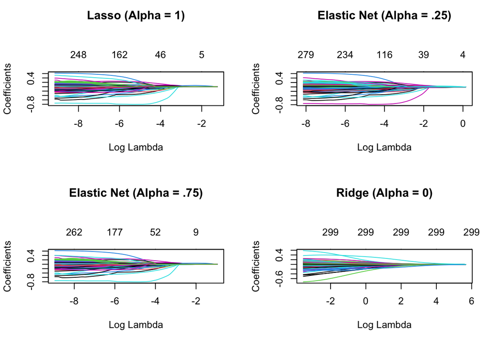

```r
#
# Elastic net regression
# First, naive manual varying of alpha
lasso    <- glmnet(ames_train_x, ames_train_y, alpha = 1.0)
elastic1 <- glmnet(ames_train_x, ames_train_y, alpha = 0.25)
elastic2 <- glmnet(ames_train_x, ames_train_y, alpha = 0.75)
ridge    <- glmnet(ames_train_x, ames_train_y, alpha = 0.0)

{
par(mfrow = c(2, 2), mar = c(6, 4, 6, 2) + 0.1)
plot(lasso, xvar = "lambda", main = "Lasso (Alpha = 1)\n\n\n")
plot(elastic1, xvar = "lambda", main = "Elastic Net (Alpha = .25)\n\n\n")
plot(elastic2, xvar = "lambda", main = "Elastic Net (Alpha = .75)\n\n\n")
plot(ridge, xvar = "lambda", main = "Ridge (Alpha = 0)\n\n\n")
par(mfrow = c(1,1))
}
```

### Grid Search

```r
# Now, more efficient grid search for varying alpha
fold_id <- sample(1:10, size = length(ames_train_y), replace = TRUE) # maintain the same folds across all models

# search across a range of alphas
tuning_grid <- tibble::tibble(
  alpha      = seq(0, 1, by = .1),
  mse_min    = NA,
  mse_1se    = NA,
  lambda_min = NA,
  lambda_1se = NA
)

library(tictoc) # time it; shouldn't take too long considering the complexity of what we are doing

{
  tic()
for(i in seq_along(tuning_grid$alpha)) {
  # fit CV model for each alpha value
  fit <- cv.glmnet(ames_train_x,
                   ames_train_y,
                   alpha = tuning_grid$alpha[i],
                   foldid = fold_id)

  # extract MSE and lambda values
  tuning_grid$mse_min[i]    <- fit$cvm[fit$lambda == fit$lambda.min]
  tuning_grid$mse_1se[i]    <- fit$cvm[fit$lambda == fit$lambda.1se]
  tuning_grid$lambda_min[i] <- fit$lambda.min
  tuning_grid$lambda_1se[i] <- fit$lambda.1se
  }
  toc()
} # took ~30 seconds on my machine (4 cores)
```

```
## 13.935 sec elapsed
```

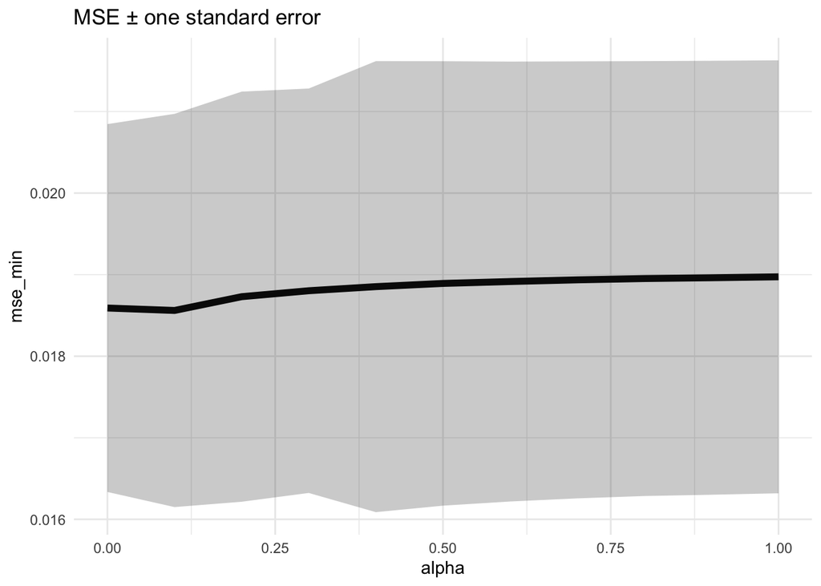

```r
# viz
tuning_grid %>%
  mutate(se = mse_1se - mse_min) %>% # navigating between min and 1-SE
  ggplot(aes(alpha, mse_min)) +
  geom_line(size = 2) +
  geom_ribbon(aes(ymax = mse_min + se,
                  ymin = mse_min - se),
              alpha = .25) +
  ggtitle("MSE ± one standard error")
```